# Elsevier 2022 SDG mapping

)

OR TITLE-ABS

(

"primary care access"

)

OR AUTHKEY

(

"primary care access"

)

OR TITLE-ABS

(

"affordable care act"

)

OR AUTHKEY

(

"affordable care act"

)

OR

(

(

TITLE-ABS("healthcare access") OR TITLE-ABS("health-care access")

)

OR

(

TITLE-ABS("healthcare access") OR TITLE-ABS("healthcare access")

)

)

OR

(

(

AUTHKEY("healthcare access") OR AUTHKEY("health-care access")

)

OR

(

AUTHKEY("healthcare access") OR AUTHKEY("healthcare access")

)

)

OR

(

TITLE-ABS

(

"barrier to medical treatment"

)

OR TITLE-ABS

(

"barriers to medical treatments"

)

)

OR

(

AUTHKEY

(

"barrier to medical treatment"

)

OR AUTHKEY

(

"barriers to medical treatments"

)

)

OR

(

(

TITLE-ABS("barrier to mental healthcare") OR TITLE-ABS("barrier to mental health-care") OR TITLE-ABS("barriers to mental healthcare") OR TITLE-ABS("barriers to mental health-care")

)

OR

(

TITLE-ABS("barrier to mental healthcare") OR TITLE-ABS("barrier to mental healthcare") OR TITLE-ABS("barriers to mental healthcare") OR TITLE-ABS("barriers to mental healthcare")

)

)

OR

(

(

AUTHKEY("barrier to mental healthcare") OR AUTHKEY("barrier to mental health-care") OR AUTHKEY("barriers to mental healthcare") OR AUTHKEY("barriers to mental health-care")

)

OR

(

AUTHKEY("barrier to mental healthcare") OR AUTHKEY("barrier to mental healthcare") OR AUTHKEY("barriers to mental healthcare") OR AUTHKEY("barriers to mental healthcare")

)

)

OR TITLE-ABS

(

"access to vaccines"

)

OR AUTHKEY

(

"access to vaccines"

)

OR

(

TITLE-ABS

(

"single-payer"

)

OR TITLE-ABS

(

"singlepayer"

)

)

OR

(

AUTHKEY

(

"single-payer"

)

OR AUTHKEY

(

"singlepayer"

)

)

OR

(

TITLE-ABS

(

"access to mental health service"

)

OR TITLE-ABS

(

"access to mental health services"

)

)

OR

(

AUTHKEY

(

"access to mental health service"

)

OR AUTHKEY

(

"access to mental health services"

)

)

OR

(

(

TITLE-ABS("healthcare for all") OR TITLE-ABS("health-care for all")

)

OR

(

TITLE-ABS("healthcare for all") OR TITLE-ABS("healthcare for all")

)

)

OR

(

(

AUTHKEY("healthcare for all") OR AUTHKEY("health-care for all")

)

OR

(

AUTHKEY("healthcare for all") OR AUTHKEY("healthcare for all")

)

)

OR

(

(

TITLE-ABS("accessing healthcare") OR TITLE-ABS("accessing health-care")

)

OR

(

TITLE-ABS("accessing healthcare") OR TITLE-ABS("accessing healthcare")

)

)

OR

(

(

AUTHKEY("accessing healthcare") OR AUTHKEY("accessing health-care")

)

OR

(

AUTHKEY("accessing healthcare") OR AUTHKEY("accessing healthcare")

)

)

OR TITLE-ABS

(

"affordable drugs"

)

OR AUTHKEY

(

"affordable drugs"

)

OR

(

TITLE-ABS

(

"barrier to mental health service"

)

OR TITLE-ABS

(

"barrier to mental health services"

)

OR TITLE-ABS

(

"barriers to mental health service"

)

OR TITLE-ABS

(

"barriers to mental health services"

)

)

OR

(

AUTHKEY

(

"barrier to mental health service"

)

OR AUTHKEY

(

"barrier to mental health services"

)

OR AUTHKEY

(

"barriers to mental health service"

)

OR AUTHKEY

(

"barriers to mental health services"

)

)

OR

(

TITLE-ABS

(

"access to mental health treatment"

)

OR TITLE-ABS

(

"access to mental health treatments"

)

)

OR

(

AUTHKEY

(

"access to mental health treatment"

)

OR AUTHKEY

(

"access to mental health treatments"

)

)

OR

(

(

TITLE-ABS("access to healthcare") OR TITLE-ABS("access to health-care")

)

OR

(

TITLE-ABS("access to healthcare") OR TITLE-ABS("access to healthcare")

)

)

OR

(

(

AUTHKEY("access to healthcare") OR AUTHKEY("access to health-care")

)

OR

(

AUTHKEY("access to healthcare") OR AUTHKEY("access to healthcare")

)

)

OR TITLE-ABS

(

"universal access to care"

)

OR AUTHKEY

(

"universal access to care"

)

OR

(

TITLE-ABS

(

"access to essential medicine"

)

OR TITLE-ABS

(

"access to essential medicines"

)

)

OR

(

AUTHKEY

(

"access to essential medicine"

)

OR AUTHKEY

(

"access to essential medicines"

)

)

OR

(

(

TITLE-ABS("accessing mental healthcare") OR TITLE-ABS("accessing mental health-care")

)

OR

(

TITLE-ABS("accessing mental healthcare") OR TITLE-ABS("accessing mental healthcare")

)

)

OR

(

(

AUTHKEY("accessing mental healthcare") OR AUTHKEY("accessing mental health-care")

)

OR

(

AUTHKEY("accessing mental healthcare") OR AUTHKEY("accessing mental healthcare")

)

)

OR TITLE-ABS

(

"medicine affordability"

)

OR AUTHKEY

(

"medicine affordability"

)

OR

(

(

TITLE-ABS("barrier to healthcare") OR TITLE-ABS("barrier to health-care") OR TITLE-ABS("barriers to healthcare") OR TITLE-ABS("barriers to health-care")

)

OR

(

TITLE-ABS("barrier to healthcare") OR TITLE-ABS("barrier to healthcare") OR TITLE-ABS("barriers to healthcare") OR TITLE-ABS("barriers to healthcare")

)

)

OR

(

(

AUTHKEY("barrier to healthcare") OR AUTHKEY("barrier to health-care") OR AUTHKEY("barriers to healthcare") OR AUTHKEY("barriers to health-care")

)

OR

(

AUTHKEY("barrier to healthcare") OR AUTHKEY("barrier to healthcare") OR AUTHKEY("barriers to healthcare") OR AUTHKEY("barriers to healthcare")

)

)

OR

(

(

TITLE-ABS("right to healthcare") OR TITLE-ABS("right to health-care")

)

OR

(

TITLE-ABS("right to healthcare") OR TITLE-ABS("right to healthcare")

)

)

OR

(

(

AUTHKEY("right to healthcare") OR AUTHKEY("right to health-care")

)

OR

(

AUTHKEY("right to healthcare") OR AUTHKEY("right to healthcare")

)

)

OR

(

TITLE-ABS

(

"access to medical treatment"

)

OR TITLE-ABS

(

"access to medical treatments"

)

)

OR

(

AUTHKEY

(

"access to medical treatment"

)

OR AUTHKEY

(

"access to medical treatments"

)

)

OR

(

TITLE-ABS

(

"access to primary health service"

)

OR TITLE-ABS

(

"access to primary health services"

)

)

OR

(

AUTHKEY

(

"access to primary health service"

)

OR AUTHKEY

(

"access to primary health services"

)

)

OR TITLE-ABS

(

"universal health insurance"

)

OR AUTHKEY

(

"universal health insurance"

)

OR

(

(

TITLE-ABS("accessibility to mental healthcare") OR TITLE-ABS("accessibility to mental health-care")

)

OR

(

TITLE-ABS("accessibility to mental healthcare") OR TITLE-ABS("accessibility to mental healthcare")

)

)

OR

(

(

AUTHKEY("accessibility to mental healthcare") OR AUTHKEY("accessibility to mental health-care")

)

OR

(

AUTHKEY("accessibility to mental healthcare") OR AUTHKEY("accessibility to mental healthcare")

)

)

OR

(

TITLE-ABS

(

"affordability of medicine"

)

OR TITLE-ABS

(

"affordability of medicines"

)

)

OR

(

AUTHKEY

(

"affordability of medicine"

)

OR AUTHKEY

(

"affordability of medicines"

)

)

OR

(

(

TITLE-ABS("healthcare accessibility") OR TITLE-ABS("health-care accessibility")

)

OR

(

TITLE-ABS("healthcare accessibility") OR TITLE-ABS("healthcare accessibility")

)

)

OR

(

(

AUTHKEY("healthcare accessibility") OR AUTHKEY("health-care accessibility")

)

OR

(

AUTHKEY("healthcare accessibility") OR AUTHKEY("healthcare accessibility")

)

)

OR TITLE-ABS

(

"Obamacare"

)

OR AUTHKEY

(

"Obamacare"

)

OR

(

TITLE-ABS

(

"barrier to primary care"

)

OR TITLE-ABS

(

"barriers to primary care"

)

)

OR

(

AUTHKEY

(

"barrier to primary care"

)

OR AUTHKEY

(

"barriers to primary care"

)

)

OR

(

TITLE-ABS

(

"accessibility to health service"

)

OR TITLE-ABS

(

"accessibility to health services"

)

)

OR

(

AUTHKEY

(

"accessibility to health service"

)

OR AUTHKEY

(

"accessibility to health services"

)

)

OR

(

TITLE-ABS

(

"access to health service"

)

OR TITLE-ABS

(

"access to health services"

)

)

OR

(

AUTHKEY

(

"access to health service"

)

OR AUTHKEY

(

"access to health services"

)

)

OR TITLE-ABS

(

"right to medical care"

)

OR AUTHKEY

(

"right to medical care"

)

OR

(

TITLE-ABS

(

"access to medicine"

)

OR TITLE-ABS

(

"access to medicines"

)

)

OR

(

AUTHKEY

(

"access to medicine"

)

OR AUTHKEY

(

"access to medicines"

)

)

OR

(

TITLE-ABS

(

"accessing mental health service"

)

OR TITLE-ABS

(

"accessing mental health services"

)

)

OR

(

AUTHKEY

(

"accessing mental health service"

)

OR AUTHKEY

(

"accessing mental health services"

)

)

OR TITLE-ABS

(

"medical care access"

)

OR AUTHKEY

(

"medical care access"

)

OR

(

TITLE-ABS

(

"affordable medicine"

)

OR TITLE-ABS

(

"affordable medicines"

)

)

OR

(

AUTHKEY

(

"affordable medicine"

)

OR AUTHKEY

(

"affordable medicines"

)

)

OR

(

TITLE-ABS

(

"health service accessibility"

)

OR TITLE-ABS

(

"health services accessibility"

)

)

OR

(

AUTHKEY

(

"health service accessibility"

)

OR AUTHKEY

(

"health services accessibility"

)

)

OR TITLE-ABS

(

"access to medical care"

)

OR AUTHKEY

(

"access to medical care"

)

)

)

OR

(

(

(

TITLE-ABS

(

"infectious disease control"

)

OR AUTHKEY

(

"infectious disease control"

)

OR

(

(TITLE-ABS("susceptible-infected-recovered-susceptible model") OR TITLE-ABS("susceptible-infected-recovered-susceptible models")) OR (TITLE-ABS("susceptibleinfectedrecoveredsusceptible model") OR TITLE-ABS("susceptibleinfectedrecoveredsusceptible models"))

)

OR

(

(AUTHKEY("susceptible-infected-recovered-susceptible model") OR AUTHKEY("susceptible-infected-recovered-susceptible models")) OR (AUTHKEY("susceptibleinfectedrecoveredsusceptible model") OR AUTHKEY("susceptibleinfectedrecoveredsusceptible models"))

)

OR TITLE-ABS

(

"prevention of pandemics"

)

OR AUTHKEY

(

"prevention of pandemics"

)

OR TITLE-ABS

(

"aids surveillance"

)

OR AUTHKEY

(

"aids surveillance"

)

OR

(

TITLE-ABS("fmd vaccine") OR TITLE-ABS("fmd vaccines")

)

OR

(

AUTHKEY("fmd vaccine") OR AUTHKEY("fmd vaccines")

)

OR

(

TITLE-ABS("outbreak model") OR TITLE-ABS("outbreak models")

)

OR

(

AUTHKEY("outbreak model") OR AUTHKEY("outbreak models")

)

OR TITLE-ABS

(

"malarial treatment"

)

OR AUTHKEY

(

"malarial treatment"

)

OR

(

TITLE-ABS("denv epidemic") OR TITLE-ABS("denv epidemics")

)

OR

(

AUTHKEY("denv epidemic") OR AUTHKEY("denv epidemics")

)

OR TITLE-ABS

(

"influenza surveillance"

)

OR AUTHKEY

(

"influenza surveillance"

)

OR TITLE-ABS

(

"prevention of influenza"

)

OR AUTHKEY

(

"prevention of influenza"

)

OR TITLE-ABS

(

"treatment of chronic hepatitis c"

)

OR AUTHKEY

(

"treatment of chronic hepatitis c"

)

OR TITLE-ABS

(

"hepatitis c virus treatment"

)

OR AUTHKEY

(

"hepatitis c virus treatment"

)

OR

(

TITLE-ABS("tb outbreak") OR TITLE-ABS("tb outbreaks")

)

OR

(

AUTHKEY("tb outbreak") OR AUTHKEY("tb outbreaks")

)

OR

(

TITLE-ABS("tuberculosis epidemic") OR TITLE-ABS("tuberculosis epidemics")

)

OR

(

AUTHKEY("tuberculosis epidemic") OR AUTHKEY("tuberculosis epidemics")

)

OR

(

TITLE-ABS("mrsa pandemic") OR TITLE-ABS("mrsa pandemics")

)

OR

(

AUTHKEY("mrsa pandemic") OR AUTHKEY("mrsa pandemics")

)

OR TITLE-ABS

(

"malaria transmission"

)

OR AUTHKEY

(

"malaria transmission"

)

OR

(

TITLE-ABS("zikv vaccine") OR TITLE-ABS("zikv vaccines")

)

OR

(

AUTHKEY("zikv vaccine") OR AUTHKEY("zikv vaccines")

)

OR

(

(TITLE-ABS("antimalaria") OR TITLE-ABS("anti-malaria")) OR (TITLE-ABS("antimalaria") OR TITLE-ABS("antimalaria"))

)

OR

(

(AUTHKEY("antimalaria") OR AUTHKEY("anti-malaria")) OR (AUTHKEY("antimalaria") OR AUTHKEY("antimalaria"))

)

OR

(

TITLE-ABS("modeling of outbreaks") OR TITLE-ABS("modelling of outbreaks")

)

OR

(

AUTHKEY("modeling of outbreaks") OR AUTHKEY("modelling of outbreaks")

)

OR TITLE-ABS

(

"response to infectious diseases"

)

OR AUTHKEY

(

"response to infectious diseases"

)

OR TITLE-ABS

(

"tuberculosis vaccination"

)

OR AUTHKEY

(

"tuberculosis vaccination"

)

OR TITLE-ABS

(

"pandemic vaccination"

)

OR AUTHKEY

(

"pandemic vaccination"

)

OR

(

TITLE-ABS("zika outbreak") OR TITLE-ABS("zika outbreaks")

)

OR

(

AUTHKEY("zika outbreak") OR AUTHKEY("zika outbreaks")

)

OR

(

TITLE-ABS("salmonella epidemic") OR TITLE-ABS("salmonella epidemics")

)

OR

(

AUTHKEY("salmonella epidemic") OR AUTHKEY("salmonella epidemics")

)

OR

(

TITLE-ABS("hiv model") OR TITLE-ABS("hiv models")

)

OR

(

AUTHKEY("hiv model") OR AUTHKEY("hiv models")

)

OR TITLE-ABS

(

"outbreak preparedness"

)

OR AUTHKEY

(

"outbreak preparedness"

)

OR TITLE-ABS

(

"meningococcal vaccination"

)

OR AUTHKEY

(

"meningococcal vaccination"

)

OR

(

TITLE-ABS("seir model") OR TITLE-ABS("seir models")

)

OR

(

AUTHKEY("seir model") OR AUTHKEY("seir models")

)

OR

(

TITLE-ABS("ebola outbreak") OR TITLE-ABS("ebola outbreaks")

)

OR

(

AUTHKEY("ebola outbreak") OR AUTHKEY("ebola outbreaks")

)

OR TITLE-ABS

(

"disease propagation"

)

OR AUTHKEY

(

"disease propagation"

)

OR

(

TITLE-ABS("sars epidemic") OR TITLE-ABS("sars epidemics")

)

OR

(

AUTHKEY("sars epidemic") OR AUTHKEY("sars epidemics")

)

OR

(

TITLE-ABS("coronavirus pandemic") OR TITLE-ABS("coronavirus pandemics")

)

OR

(

AUTHKEY("coronavirus pandemic") OR AUTHKEY("coronavirus pandemics")

)

OR TITLE-ABS

(

"pertussis vaccination"

)

OR AUTHKEY

(

"pertussis vaccination"

)

OR

(

TITLE-ABS("malaria drug") OR TITLE-ABS("malaria drugs")

)

OR

(

AUTHKEY("malaria drug") OR AUTHKEY("malaria drugs")

)

OR TITLE-ABS

(

"pandemic virus"

)

OR AUTHKEY

(

"pandemic virus"

)

OR TITLE-ABS

(

"epidemic meningitis"

)

OR AUTHKEY

(

"epidemic meningitis"

)

OR

(

TITLE-ABS("bacille-calmette-guerin vaccination") OR TITLE-ABS("bacillecalmetteguerin vaccination")

)

OR

(

AUTHKEY("bacille-calmette-guerin vaccination") OR AUTHKEY("bacillecalmetteguerin vaccination")

)

OR TITLE-ABS

(

"viral propagation"

)

OR AUTHKEY

(

"viral propagation"

)

OR

(

TITLE-ABS("influenza epidemic") OR TITLE-ABS("influenza epidemics")

)

OR

(

AUTHKEY("influenza epidemic") OR AUTHKEY("influenza epidemics")

)

OR

(

TITLE-ABS("tuberculosis outbreak") OR TITLE-ABS("tuberculosis outbreaks")

)

OR

(

AUTHKEY("tuberculosis outbreak") OR AUTHKEY("tuberculosis outbreaks")

)

OR TITLE-ABS

(

"spread of outbreaks"

)

OR AUTHKEY

(

"spread of outbreaks"

)

OR TITLE-ABS

(

"aids education"

)

OR AUTHKEY

(

"aids education"

)

OR

(

TITLE-ABS("virus outbreak") OR TITLE-ABS("virus outbreaks")

)

OR

(

AUTHKEY("virus outbreak") OR AUTHKEY("virus outbreaks")

)

OR

(

TITLE-ABS("botulism outbreak") OR TITLE-ABS("botulism outbreaks")

)

OR

(

AUTHKEY("botulism outbreak") OR AUTHKEY("botulism outbreaks")

)

OR TITLE-ABS

(

"measles prevention"

)

OR AUTHKEY

(

"measles prevention"

)

OR TITLE-ABS

(

"management of outbreaks"

)

OR AUTHKEY

(

"management of outbreaks"

)

OR

(

TITLE-ABS("cholera vaccine") OR TITLE-ABS("cholera vaccines")

)

OR

(

AUTHKEY("cholera vaccine") OR AUTHKEY("cholera vaccines")

)

OR TITLE-ABS

(

"epidemic forecasting"

)

OR AUTHKEY

(

"epidemic forecasting"

)

OR TITLE-ABS

(

"malaria prevention"

)

OR AUTHKEY

(

"malaria prevention"

)

OR

(

TITLE-ABS("outbreak of zika") OR TITLE-ABS("outbreaks of zika")

)

OR

(

AUTHKEY("outbreak of zika") OR AUTHKEY("outbreaks of zika")

)

OR TITLE-ABS

(

"plague prevention"

)

OR AUTHKEY

(

"plague prevention"

)

OR TITLE-ABS

(

"pandemic surveillance"

)

OR AUTHKEY

(

"pandemic surveillance"

)

OR

(

TITLE-ABS("mmr vaccine") OR TITLE-ABS("mmr vaccines")

)

OR

(

AUTHKEY("mmr vaccine") OR AUTHKEY("mmr vaccines")

)

OR TITLE-ABS

(

"knowledge about aids"

)

OR AUTHKEY

(

"knowledge about aids"

)

OR TITLE-ABS

(

"transmission of hepatitis c"

)

OR AUTHKEY

(

"transmission of hepatitis c"

)

OR TITLE-ABS

(

"tb vaccination"

)

OR AUTHKEY

(

"tb vaccination"

)

OR

(

TITLE-ABS("h1n1 vaccine") OR TITLE-ABS("h1n1 vaccines")

)

OR

(

AUTHKEY("h1n1 vaccine") OR AUTHKEY("h1n1 vaccines")

)

OR TITLE-ABS

(

"pandemic control"

)

OR AUTHKEY

(

"pandemic control"

)

OR TITLE-ABS

(

"treatment of infectious diseases"

)

OR AUTHKEY

(

"treatment of infectious diseases"

)

OR

(

TITLE-ABS("seirs epidemic") OR TITLE-ABS("seirs epidemics")

)

OR

(

AUTHKEY("seirs epidemic") OR AUTHKEY("seirs epidemics")

)

OR

(

TITLE-ABS("influenza vaccine") OR TITLE-ABS("influenza vaccines")

)

OR

(

AUTHKEY("influenza vaccine") OR AUTHKEY("influenza vaccines")

)

OR

(

TITLE-ABS("fmd epidemic") OR TITLE-ABS("fmd epidemics")

)

OR

(

AUTHKEY("fmd epidemic") OR AUTHKEY("fmd epidemics")

)

OR

(

TITLE-ABS("malaria vaccine") OR TITLE-ABS("malaria vaccines")

)

OR

(

AUTHKEY("malaria vaccine") OR AUTHKEY("malaria vaccines")

)

OR

(

TITLE-ABS("gastroenteritis outbreak") OR TITLE-ABS("gastroenteritis outbreaks")

)

OR

(

AUTHKEY("gastroenteritis outbreak") OR AUTHKEY("gastroenteritis outbreaks")

)

OR TITLE-ABS

(

"hiv education"

)

OR AUTHKEY

(

"hiv education"

)

OR

(

TITLE-ABS("listeriosis outbreak") OR TITLE-ABS("listeriosis outbreaks")

)

OR

(

AUTHKEY("listeriosis outbreak") OR AUTHKEY("listeriosis outbreaks")

)

OR

(

TITLE-ABS("zikv epidemic") OR TITLE-ABS("zikv epidemics")

)

OR

(

AUTHKEY("zikv epidemic") OR AUTHKEY("zikv epidemics")

)

OR TITLE-ABS

(

"tuberculosis control"

)

OR AUTHKEY

(

"tuberculosis control"

)

OR TITLE-ABS

(

"mrsa transmission"

)

OR AUTHKEY

(

"mrsa transmission"

)

OR

(

TITLE-ABS("tb drug") OR TITLE-ABS("tb drugs")

)

OR

(

AUTHKEY("tb drug") OR AUTHKEY("tb drugs")

)

OR

(

TITLE-ABS("hepatitis c pandemic") OR TITLE-ABS("hepatitis c pandemics")

)

OR

(

AUTHKEY("hepatitis c pandemic") OR AUTHKEY("hepatitis c pandemics")

)

OR TITLE-ABS

(

"influenza preparedness"

)

OR AUTHKEY

(

"influenza preparedness"

)

OR TITLE-ABS

(

"prevention of tuberculosis"

)

OR AUTHKEY

(

"prevention of tuberculosis"

)

OR TITLE-ABS

(

"measles eradication"

)

OR AUTHKEY

(

"measles eradication"

)

OR TITLE-ABS

(

"tuberculosis therapy"

)

OR AUTHKEY

(

"tuberculosis therapy"

)

OR

(

TITLE-ABS("mrsa epidemic") OR TITLE-ABS("mrsa epidemics")

)

OR

(

AUTHKEY("mrsa epidemic") OR AUTHKEY("mrsa epidemics")

)

OR

(

TITLE-ABS("aids outbreak") OR TITLE-ABS("aids outbreaks")

)

OR

(

AUTHKEY("aids outbreak") OR AUTHKEY("aids outbreaks")

)

OR TITLE-ABS

(

"outbreak surveillance"

)

OR AUTHKEY

(

"outbreak surveillance"

)

OR TITLE-ABS

(

"prevention of epidemics"

)

OR AUTHKEY

(

"prevention of epidemics"

)

OR TITLE-ABS

(

"spread of aids"

)

OR AUTHKEY

(

"spread of aids"

)

OR TITLE-ABS

(

"ebola treatment"

)

OR AUTHKEY

(

"ebola treatment"

)

OR TITLE-ABS

(

"control of outbreaks"

)

OR AUTHKEY

(

"control of outbreaks"

)

OR TITLE-ABS

(

"ebola control"

)

OR AUTHKEY

(

"ebola control"

)

OR

(

(TITLE-ABS("waterborne outbreak") OR TITLE-ABS("water-borne outbreak") OR TITLE-ABS("waterborne outbreaks") OR TITLE-ABS("water-borne outbreaks")) OR (TITLE-ABS("waterborne outbreak") OR TITLE-ABS("waterborne outbreak") OR TITLE-ABS("waterborne outbreaks") OR TITLE-ABS("waterborne outbreaks"))

)

OR

(

(AUTHKEY("waterborne outbreak") OR AUTHKEY("water-borne outbreak") OR AUTHKEY("waterborne outbreaks") OR AUTHKEY("water-borne outbreaks")) OR (AUTHKEY("waterborne outbreak") OR AUTHKEY("waterborne outbreak") OR AUTHKEY("waterborne outbreaks") OR AUTHKEY("waterborne outbreaks"))

)

OR TITLE-ABS

(

"hiv prevention"

)

OR AUTHKEY

(

"hiv prevention"

)

OR TITLE-ABS

(

"outbreak control"

)

OR AUTHKEY

(

"outbreak control"

)

OR TITLE-ABS

(

"viral transmission"

)

OR AUTHKEY

(

"viral transmission"

)

OR TITLE-ABS

(

"measles vaccination"

)

OR AUTHKEY

(

"measles vaccination"

)

OR

(

TITLE-ABS("bcg vaccine") OR TITLE-ABS("bcg vaccines")

)

OR

(

AUTHKEY("bcg vaccine") OR AUTHKEY("bcg vaccines")

)

OR

(

TITLE-ABS("infectious outbreak") OR TITLE-ABS("infectious outbreaks")

)

OR

(

AUTHKEY("infectious outbreak") OR AUTHKEY("infectious outbreaks")

)

OR TITLE-ABS

(

"spread of diseases"

)

OR AUTHKEY

(

"spread of diseases"

)

OR TITLE-ABS

(

"hcv eradication"

)

OR AUTHKEY

(

"hcv eradication"

)

OR

(

TITLE-ABS("mers outbreak") OR TITLE-ABS("mers outbreaks")

)

OR

(

AUTHKEY("mers outbreak") OR AUTHKEY("mers outbreaks")

)

OR TITLE-ABS

(

"malaria knowledge"

)

OR AUTHKEY

(

"malaria knowledge"

)

OR TITLE-ABS

(

"disease transmission"

)

OR AUTHKEY

(

"disease transmission"

)

OR

(

TITLE-ABS("dengue model") OR TITLE-ABS("dengue models")

)

OR

(

AUTHKEY("dengue model") OR AUTHKEY("dengue models")

)

OR TITLE-ABS

(

"epidemic detection"

)

OR AUTHKEY

(

"epidemic detection"

)

OR

(

TITLE-ABS("evd outbreak") OR TITLE-ABS("evd outbreaks")

)

OR

(

AUTHKEY("evd outbreak") OR AUTHKEY("evd outbreaks")

)

OR TITLE-ABS

(

"virus transmission"

)

OR AUTHKEY

(

"virus transmission"

)

OR TITLE-ABS

(

"surveillance of epidemics"

)

OR AUTHKEY

(

"surveillance of epidemics"

)

OR

(

TITLE-ABS("chikungunya outbreak") OR TITLE-ABS("chikungunya outbreaks")

)

OR

(

AUTHKEY("chikungunya outbreak") OR AUTHKEY("chikungunya outbreaks")

)

OR

(

TITLE-ABS("rubella epidemic") OR TITLE-ABS("rubella epidemics")

)

OR

(

AUTHKEY("rubella epidemic") OR AUTHKEY("rubella epidemics")

)

OR

(

TITLE-ABS("viral epidemic") OR TITLE-ABS("viral epidemics")

)

OR

(

AUTHKEY("viral epidemic") OR AUTHKEY("viral epidemics")

)

OR TITLE-ABS

(

"pandemic preparedness"

)

OR AUTHKEY

(

"pandemic preparedness"

)

OR

(

TITLE-ABS("outbreak vaccine") OR TITLE-ABS("outbreak vaccines")

)

OR

(

AUTHKEY("outbreak vaccine") OR AUTHKEY("outbreak vaccines")

)

OR TITLE-ABS

(

"tb therapy"

)

OR AUTHKEY

(

"tb therapy"

)

OR TITLE-ABS

(

"plague control"

)

OR AUTHKEY

(

"plague control"

)

OR TITLE-ABS

(

"epidemic spread"

)

OR AUTHKEY

(

"epidemic spread"

)

OR TITLE-ABS

(

"control of tuberculosis"

)

OR AUTHKEY

(

"control of tuberculosis"

)

OR TITLE-ABS

(

"cholera transmission"

)

OR AUTHKEY

(

"cholera transmission"

)

OR

(

TITLE-ABS("viral infection model") OR TITLE-ABS("viral infection models")

)

OR

(

AUTHKEY("viral infection model") OR AUTHKEY("viral infection models")

)

OR

(

TITLE-ABS("h1n1 outbreak") OR TITLE-ABS("h1n1 outbreaks")

)

OR

(

AUTHKEY("h1n1 outbreak") OR AUTHKEY("h1n1 outbreaks")

)

OR

(

TITLE-ABS("pertussis epidemic") OR TITLE-ABS("pertussis epidemics")

)

OR

(

AUTHKEY("pertussis epidemic") OR AUTHKEY("pertussis epidemics")

)

OR TITLE-ABS

(

"transmission of aids"

)

OR AUTHKEY

(

"transmission of aids"

)

OR TITLE-ABS

(

"outbreak detection"

)

OR AUTHKEY

(

"outbreak detection"

)

OR TITLE-ABS

(

"tb elimination"

)

OR AUTHKEY

(

"tb elimination"

)

OR TITLE-ABS

(

"prevention of hepatitis c"

)

OR AUTHKEY

(

"prevention of hepatitis c"

)

OR

(

TITLE-ABS("hiv epidemic") OR TITLE-ABS("hiv epidemics")

)

OR

(

AUTHKEY("hiv epidemic") OR AUTHKEY("hiv epidemics")

)

OR

(

TITLE-ABS("norovirus outbreak") OR TITLE-ABS("norovirus outbreaks")

)

OR

(

AUTHKEY("norovirus outbreak") OR AUTHKEY("norovirus outbreaks")

)

OR TITLE-ABS

(

"transmission of infectious diseases"

)

OR AUTHKEY

(

"transmission of infectious diseases"

)

OR

(

(TITLE-ABS("susceptible-exposed-infectious-recovered-susceptible model") OR TITLE-ABS("susceptible-exposed-infectious-recovered-susceptible models")) OR (TITLE-ABS("susceptibleexposedinfectiousrecoveredsusceptible model") OR TITLE-ABS("susceptibleexposedinfectiousrecoveredsusceptible models"))

)

OR

(

(AUTHKEY("susceptible-exposed-infectious-recovered-susceptible model") OR AUTHKEY("susceptible-exposed-infectious-recovered-susceptible models")) OR (AUTHKEY("susceptibleexposedinfectiousrecoveredsusceptible model") OR AUTHKEY("susceptibleexposedinfectiousrecoveredsusceptible models"))

)

OR

(

TITLE-ABS("cholera epidemic") OR TITLE-ABS("cholera epidemics")

)

OR

(

AUTHKEY("cholera epidemic") OR AUTHKEY("cholera epidemics")

)

OR TITLE-ABS

(

"dengue vaccination"

)

OR AUTHKEY

(

"dengue vaccination"

)

OR

(

TITLE-ABS("flu vaccine") OR TITLE-ABS("flu vaccines")

)

OR

(

AUTHKEY("flu vaccine") OR AUTHKEY("flu vaccines")

)

OR

(

TITLE-ABS("zikv outbreak") OR TITLE-ABS("zikv outbreaks")

)

OR

(

AUTHKEY("zikv outbreak") OR AUTHKEY("zikv outbreaks")

)

OR TITLE-ABS

(

"hepatitis c transmission"

)

OR AUTHKEY

(

"hepatitis c transmission"

)

OR

(

TITLE-ABS("tuberculosis drug") OR TITLE-ABS("tuberculosis drugs")

)

OR

(

AUTHKEY("tuberculosis drug") OR AUTHKEY("tuberculosis drugs")

)

OR TITLE-ABS

(

"influenza prevention"

)

OR AUTHKEY

(

"influenza prevention"

)

OR TITLE-ABS

(

"spread of hiv"

)

OR AUTHKEY

(

"spread of hiv"

)

OR TITLE-ABS

(

"epidemic prevention"

)

OR AUTHKEY

(

"epidemic prevention"

)

OR TITLE-ABS

(

"protection against pertussis"

)

OR AUTHKEY

(

"protection against pertussis"

)

OR TITLE-ABS

(

"mrsa eradication"

)

OR AUTHKEY

(

"mrsa eradication"

)

OR TITLE-ABS

(

"propagation of viruses"

)

OR AUTHKEY

(

"propagation of viruses"

)

OR TITLE-ABS

(

"outbreak vaccination"

)

OR AUTHKEY

(

"outbreak vaccination"

)

OR TITLE-ABS

(

"wnv transmission"

)

OR AUTHKEY

(

"wnv transmission"

)

OR TITLE-ABS

(

"tuberculosis transmission"

)

OR AUTHKEY

(

"tuberculosis transmission"

)

OR TITLE-ABS

(

"detection of infectious diseases"

)

OR AUTHKEY

(

"detection of infectious diseases"

)

OR

(

TITLE-ABS("ebola epidemic") OR TITLE-ABS("ebola epidemics")

)

OR

(

AUTHKEY("ebola epidemic") OR AUTHKEY("ebola epidemics")

)

OR TITLE-ABS

(

"hiv treatment"

)

OR AUTHKEY

(

"hiv treatment"

)

OR

(

TITLE-ABS("anthrax outbreak") OR TITLE-ABS("anthrax outbreaks")

)

OR

(

AUTHKEY("anthrax outbreak") OR AUTHKEY("anthrax outbreaks")

)

OR

(

TITLE-ABS("meningococcal conjugate vaccine") OR TITLE-ABS("meningococcal conjugate vaccines")

)

OR

(

AUTHKEY("meningococcal conjugate vaccine") OR AUTHKEY("meningococcal conjugate vaccines")

)

OR

(

TITLE-ABS("infectious pandemic") OR TITLE-ABS("infectious pandemics")

)

OR

(

AUTHKEY("infectious pandemic") OR AUTHKEY("infectious pandemics")

)

OR TITLE-ABS

(

"spread of epidemics"

)

OR AUTHKEY

(

"spread of epidemics"

)

OR

(

TITLE-ABS("measles vaccine") OR TITLE-ABS("measles vaccines")

)

OR

(

AUTHKEY("measles vaccine") OR AUTHKEY("measles vaccines")

)

OR TITLE-ABS

(

"hcv prevention"

)

OR AUTHKEY

(

"hcv prevention"

)

OR TITLE-ABS

(

"influenza control"

)

OR AUTHKEY

(

"influenza control"

)

OR

(

TITLE-ABS("coronavirus epidemic") OR TITLE-ABS("coronavirus epidemics")

)

OR

(

AUTHKEY("coronavirus epidemic") OR AUTHKEY("coronavirus epidemics")

)

OR

(

TITLE-ABS("mers pandemic") OR TITLE-ABS("mers pandemics")

)

OR

(

AUTHKEY("mers pandemic") OR AUTHKEY("mers pandemics")

)

OR

(

TITLE-ABS("malaria outbreak") OR TITLE-ABS("malaria outbreaks")

)

OR

(

AUTHKEY("malaria outbreak") OR AUTHKEY("malaria outbreaks")

)

OR

(

TITLE-ABS("disease epidemic") OR TITLE-ABS("disease epidemics")

)

OR

(

AUTHKEY("disease epidemic") OR AUTHKEY("disease epidemics")

)

OR

(

TITLE-ABS("epidemic disease") OR TITLE-ABS("epidemic diseases")

)

OR

(

AUTHKEY("epidemic disease") OR AUTHKEY("epidemic diseases")

)

OR TITLE-ABS

(

"black death"

)

OR AUTHKEY

(

"black death"

)

OR

(

TITLE-ABS("measles outbreak") OR TITLE-ABS("measles outbreaks")

)

OR

(

AUTHKEY("measles outbreak") OR AUTHKEY("measles outbreaks")

)

OR TITLE-ABS

(

"epidemic treatment"

)

OR AUTHKEY

(

"epidemic treatment"

)

OR

(

TITLE-ABS("epidemic model") OR TITLE-ABS("epidemic models")

)

OR

(

AUTHKEY("epidemic model") OR AUTHKEY("epidemic models")

)

OR TITLE-ABS

(

"aids awareness"

)

OR AUTHKEY

(

"aids awareness"

)

OR

(

TITLE-ABS("flu outbreak") OR TITLE-ABS("flu outbreaks")

)

OR

(

AUTHKEY("flu outbreak") OR AUTHKEY("flu outbreaks")

)

OR TITLE-ABS

(

"tb transmission"

)

OR AUTHKEY

(

"tb transmission"

)

OR TITLE-ABS

(

"infectious disease surveillance"

)

OR AUTHKEY

(

"infectious disease surveillance"

)

OR

(

TITLE-ABS("viral outbreak") OR TITLE-ABS("viral outbreaks")

)

OR

(

AUTHKEY("viral outbreak") OR AUTHKEY("viral outbreaks")

)

OR

(

TITLE-ABS("outbreak of meningitis") OR TITLE-ABS("outbreaks of meningitis")

)

OR

(

AUTHKEY("outbreak of meningitis") OR AUTHKEY("outbreaks of meningitis")

)

OR TITLE-ABS

(

"pandemic planning"

)

OR AUTHKEY

(

"pandemic planning"

)

OR TITLE-ABS

(

"malaria awareness"

)

OR AUTHKEY

(

"malaria awareness"

)

OR TITLE-ABS

(

"transmission of viruses"

)

OR AUTHKEY

(

"transmission of viruses"

)

OR

(

TITLE-ABS("pertussis outbreak") OR TITLE-ABS("pertussis outbreaks")

)

OR

(

AUTHKEY("pertussis outbreak") OR AUTHKEY("pertussis outbreaks")

)

OR TITLE-ABS

(

"next generation matrix"

)

OR AUTHKEY

(

"next generation matrix"

)

OR

(

TITLE-ABS("h1n1 pandemic") OR TITLE-ABS("h1n1 pandemics")

)

OR

(

AUTHKEY("h1n1 pandemic") OR AUTHKEY("h1n1 pandemics")

)

OR TITLE-ABS

(

"rubella vaccination"

)

OR AUTHKEY

(

"rubella vaccination"

)

OR

(

TITLE-ABS("epidemic vaccine") OR TITLE-ABS("epidemic vaccines")

)

OR

(

AUTHKEY("epidemic vaccine") OR AUTHKEY("epidemic vaccines")

)

OR TITLE-ABS

(

"cholera treatment"

)

OR AUTHKEY

(

"cholera treatment"

)

OR

(

TITLE-ABS("denv outbreak") OR TITLE-ABS("denv outbreaks")

)

OR

(

AUTHKEY("denv outbreak") OR AUTHKEY("denv outbreaks")

)

OR

(

TITLE-ABS("cholera pandemic") OR TITLE-ABS("cholera pandemics")

)

OR

(

AUTHKEY("cholera pandemic") OR AUTHKEY("cholera pandemics")

)

OR

(

(TITLE-ABS("susceptible-infected-susceptible model") OR TITLE-ABS("susceptible-infected-susceptible models")) OR (TITLE-ABS("susceptibleinfectedsusceptible model") OR TITLE-ABS("susceptibleinfectedsusceptible models"))

)

OR

(

(AUTHKEY("susceptible-infected-susceptible model") OR AUTHKEY("susceptible-infected-susceptible models")) OR (AUTHKEY("susceptibleinfectedsusceptible model") OR AUTHKEY("susceptibleinfectedsusceptible models"))

)

OR TITLE-ABS

(

"hiv awareness"

)

OR AUTHKEY

(

"hiv awareness"

)

OR

(

TITLE-ABS("virus infection model") OR TITLE-ABS("virus infection models")

)

OR

(

AUTHKEY("virus infection model") OR AUTHKEY("virus infection models")

)

OR

(

(TITLE-ABS("foodborne outbreak") OR TITLE-ABS("food-borne outbreak") OR TITLE-ABS("foodborne outbreaks") OR TITLE-ABS("food-borne outbreaks")) OR (TITLE-ABS("foodborne outbreak") OR TITLE-ABS("foodborne outbreak") OR TITLE-ABS("foodborne outbreaks") OR TITLE-ABS("foodborne outbreaks"))

)

OR

(

(AUTHKEY("foodborne outbreak") OR AUTHKEY("food-borne outbreak") OR AUTHKEY("foodborne outbreaks") OR AUTHKEY("food-borne outbreaks")) OR (AUTHKEY("foodborne outbreak") OR AUTHKEY("foodborne outbreak") OR AUTHKEY("foodborne outbreaks") OR AUTHKEY("foodborne outbreaks"))

)

OR TITLE-ABS

(

"malaria treatment"

)

OR AUTHKEY

(

"malaria treatment"

)

OR TITLE-ABS

(

"tb prevention"

)

OR AUTHKEY

(

"tb prevention"

)

OR TITLE-ABS

(

"surveillance of mrsa"

)

OR AUTHKEY

(

"surveillance of mrsa"

)

OR

(

TITLE-ABS("tuberculosis pandemic") OR TITLE-ABS("tuberculosis pandemics")

)

OR

(

AUTHKEY("tuberculosis pandemic") OR AUTHKEY("tuberculosis pandemics")

)

OR TITLE-ABS

(

"treatment of tb"

)

OR AUTHKEY

(

"treatment of tb"

)

OR TITLE-ABS

(

"influenza treatment"

)

OR AUTHKEY

(

"influenza treatment"

)

OR

(

(TITLE-ABS("aids model") OR TITLE-ABS("aids models")) AND NOT (TITLE-ABS("almost ideal demand system"))

)

OR

(

(AUTHKEY("aids model") OR AUTHKEY("aids models")) AND NOT (AUTHKEY("almost ideal demand system"))

)

OR

(

TITLE-ABS("plague vaccine") OR TITLE-ABS("plague vaccines")

)

OR

(

AUTHKEY("plague vaccine") OR AUTHKEY("plague vaccines")

)

OR TITLE-ABS

(

"dengue prevention"

)

OR AUTHKEY

(

"dengue prevention"

)

OR

(

TITLE-ABS("ebola pandemic") OR TITLE-ABS("ebola pandemics")

)

OR

(

AUTHKEY("ebola pandemic") OR AUTHKEY("ebola pandemics")

)

OR

(

TITLE-ABS("modeling of pandemics") OR TITLE-ABS("modelling of pandemics")

)

OR

(

AUTHKEY("modeling of pandemics") OR AUTHKEY("modelling of pandemics")

)

OR

(

TITLE-ABS("aids epidemic") OR TITLE-ABS("aids epidemics")

)

OR

(

AUTHKEY("aids epidemic") OR AUTHKEY("aids epidemics")

)

OR

(

TITLE-ABS("plague epidemic") OR TITLE-ABS("plague epidemics")

)

OR

(

AUTHKEY("plague epidemic") OR AUTHKEY("plague epidemics")

)

OR TITLE-ABS

(

"virus spread"

)

OR AUTHKEY

(

"virus spread"

)

OR

(

TITLE-ABS("sirs model") OR TITLE-ABS("sirs models")

)

OR

(

AUTHKEY("sirs model") OR AUTHKEY("sirs models")

)

OR

(

TITLE-ABS("meningitis pandemic") OR TITLE-ABS("meningitis pandemics")

)

OR

(

AUTHKEY("meningitis pandemic") OR AUTHKEY("meningitis pandemics")

)

OR

(

(TITLE-ABS("antimalarial") OR TITLE-ABS("anti-malarial")) OR (TITLE-ABS("antimalarial") OR TITLE-ABS("antimalarial"))

)

OR

(

(AUTHKEY("antimalarial") OR AUTHKEY("anti-malarial")) OR (AUTHKEY("antimalarial") OR AUTHKEY("antimalarial"))

)

OR TITLE-ABS

(

"measles control"

)

OR AUTHKEY

(

"measles control"

)

OR

(

TITLE-ABS("zika pandemic") OR TITLE-ABS("zika pandemics")

)

OR

(

AUTHKEY("zika pandemic") OR AUTHKEY("zika pandemics")

)

OR TITLE-ABS

(

"prevention of malaria"

)

OR AUTHKEY

(

"prevention of malaria"

)

OR TITLE-ABS

(

"response to outbreaks"

)

OR AUTHKEY

(

"response to outbreaks"

)

OR TITLE-ABS

(

"outbreak prevention"

)

OR AUTHKEY

(

"outbreak prevention"

)

OR

(

TITLE-ABS("wnv epidemic") OR TITLE-ABS("wnv epidemics")

)

OR

(

AUTHKEY("wnv epidemic") OR AUTHKEY("wnv epidemics")

)

OR TITLE-ABS

(

"aids vaccination"

)

OR AUTHKEY

(

"aids vaccination"

)

OR

(

TITLE-ABS("salmonella outbreak") OR TITLE-ABS("salmonella outbreaks")

)

OR

(

AUTHKEY("salmonella outbreak") OR AUTHKEY("salmonella outbreaks")

)

OR TITLE-ABS

(

"propagation of infectious diseases"

)

OR AUTHKEY

(

"propagation of infectious diseases"

)

OR

(

TITLE-ABS("malaria epidemic") OR TITLE-ABS("malaria epidemics")

)

OR

(

AUTHKEY("malaria epidemic") OR AUTHKEY("malaria epidemics")

)

OR

(

TITLE-ABS("meningococcal vaccine") OR TITLE-ABS("meningococcal vaccines")

)

OR

(

AUTHKEY("meningococcal vaccine") OR AUTHKEY("meningococcal vaccines")

)

OR

(

TITLE-ABS("pandemic wave") OR TITLE-ABS("pandemic waves")

)

OR

(

AUTHKEY("pandemic wave") OR AUTHKEY("pandemic waves")

)

OR

(

TITLE-ABS("pertussis vaccine") OR TITLE-ABS("pertussis vaccines")

)

OR

(

AUTHKEY("pertussis vaccine") OR AUTHKEY("pertussis vaccines")

)

OR

(

TITLE-ABS("disease-free equilibrium") OR TITLE-ABS("diseasefree equilibrium")

)

OR

(

AUTHKEY("disease-free equilibrium") OR AUTHKEY("diseasefree equilibrium")

)

OR TITLE-ABS

(

"viral spread"

)

OR AUTHKEY

(

"viral spread"

)

OR

(

(TITLE-ABS("bacille-calmette-guerin vaccine") OR TITLE-ABS("bacille-calmette-guerin vaccines")) OR (TITLE-ABS("bacillecalmetteguerin vaccine") OR TITLE-ABS("bacillecalmetteguerin vaccines"))

)

OR

(

(AUTHKEY("bacille-calmette-guerin vaccine") OR AUTHKEY("bacille-calmette-guerin vaccines")) OR (AUTHKEY("bacillecalmetteguerin vaccine") OR AUTHKEY("bacillecalmetteguerin vaccines"))

)

OR TITLE-ABS

(

"management of pandemics"

)

OR AUTHKEY

(

"management of pandemics"

)

OR

(

TITLE-ABS("influenza outbreak") OR TITLE-ABS("influenza outbreaks")

)

OR

(

AUTHKEY("influenza outbreak") OR AUTHKEY("influenza outbreaks")

)

OR TITLE-ABS

(

"measles surveillance"

)

OR AUTHKEY

(

"measles surveillance"

)

OR

(

TITLE-ABS("hepatitis c epidemic") OR TITLE-ABS("hepatitis c epidemics")

)

OR

(

AUTHKEY("hepatitis c epidemic") OR AUTHKEY("hepatitis c epidemics")

)

OR TITLE-ABS

(

"disease spread"

)

OR AUTHKEY

(

"disease spread"

)

OR TITLE-ABS

(

"spread of pandemics"

)

OR AUTHKEY

(

"spread of pandemics"

)

OR TITLE-ABS

(

"knowledge of hiv"

)

OR AUTHKEY

(

"knowledge of hiv"

)

OR

(

TITLE-ABS("tuberculosis vaccine") OR TITLE-ABS("tuberculosis vaccines")

)

OR

(

AUTHKEY("tuberculosis vaccine") OR AUTHKEY("tuberculosis vaccines")

)

OR TITLE-ABS

(

"malaria surveillance"

)

OR AUTHKEY

(

"malaria surveillance"

)

OR TITLE-ABS

(

"control of mrsa"

)

OR AUTHKEY

(

"control of mrsa"

)

OR

(

TITLE-ABS("modeling of infectious diseases") OR TITLE-ABS("modelling of infectious diseases")

)

OR

(

AUTHKEY("modeling of infectious diseases") OR AUTHKEY("modelling of infectious diseases")

)

OR

(

TITLE-ABS("epidemic outbreak") OR TITLE-ABS("epidemic outbreaks")

)

OR

(

AUTHKEY("epidemic outbreak") OR AUTHKEY("epidemic outbreaks")

)

OR TITLE-ABS

(

"transmission of zika"

)

OR AUTHKEY

(

"transmission of zika"

)

OR

(

TITLE-ABS("tb vaccine") OR TITLE-ABS("tb vaccines")

)

OR

(

AUTHKEY("tb vaccine") OR AUTHKEY("tb vaccines")

)

OR

(

TITLE-ABS("gastroenteritis pandemic") OR TITLE-ABS("gastroenteritis pandemics")

)

OR

(

AUTHKEY("gastroenteritis pandemic") OR AUTHKEY("gastroenteritis pandemics")

)

OR TITLE-ABS

(

"pandemic detection"

)

OR AUTHKEY

(

"pandemic detection"

)

OR TITLE-ABS

(

"pandemic h1n1"

)

OR AUTHKEY

(

"pandemic h1n1"

)

OR

(

TITLE-ABS("sir epidemic") OR TITLE-ABS("sir epidemics")

)

OR

(

AUTHKEY("sir epidemic") OR AUTHKEY("sir epidemics")

)

OR

(

TITLE-ABS("pandemic modeling") OR TITLE-ABS("pandemic modelling")

)

OR

(

AUTHKEY("pandemic modeling") OR AUTHKEY("pandemic modelling")

)

OR TITLE-ABS

(

"treatment of outbreaks"

)

OR AUTHKEY

(

"treatment of outbreaks"

)

OR

(

TITLE-ABS("malarial drug") OR TITLE-ABS("malarial drugs")

)

OR

(

AUTHKEY("malarial drug") OR AUTHKEY("malarial drugs")

)

OR

(

TITLE-ABS("gastroenteritis epidemic") OR TITLE-ABS("gastroenteritis epidemics")

)

OR

(

AUTHKEY("gastroenteritis epidemic") OR AUTHKEY("gastroenteritis epidemics")

)

OR TITLE-ABS

(

"detection of norovirus"

)

OR AUTHKEY

(

"detection of norovirus"

)

OR TITLE-ABS

(

"norovirus detection"

)

OR AUTHKEY

(

"norovirus detection"

)

OR TITLE-ABS

(

"influenza virus detection"

)

OR AUTHKEY

(

"influenza virus detection"

)

OR TITLE-ABS

(

"treatment of tuberculosis"

)

OR AUTHKEY

(

"treatment of tuberculosis"

)

OR

(

TITLE-ABS("zika vaccine") OR TITLE-ABS("zika vaccines")

)

OR

(

AUTHKEY("zika vaccine") OR AUTHKEY("zika vaccines")

)

OR TITLE-ABS

(

"prevention of aids"

)

OR AUTHKEY

(

"prevention of aids"

)

OR TITLE-ABS

(

"tb control"

)

OR AUTHKEY

(

"tb control"

)

OR TITLE-ABS

(

"meningitis surveillance"

)

OR AUTHKEY

(

"meningitis surveillance"

)

OR TITLE-ABS

(

"measles elimination"

)

OR AUTHKEY

(

"measles elimination"

)

OR TITLE-ABS

(

"dengue surveillance"

)

OR AUTHKEY

(

"dengue surveillance"

)

OR TITLE-ABS

(

"virus spreading"

)

OR AUTHKEY

(

"virus spreading"

)

OR

(

TITLE-ABS("sis model") OR TITLE-ABS("sis models")

)

OR

(

AUTHKEY("sis model") OR AUTHKEY("sis models")

)

OR TITLE-ABS

(

"prevention of mrsa"

)

OR AUTHKEY

(

"prevention of mrsa"

)

OR TITLE-ABS

(

"control of pandemics"

)

OR AUTHKEY

(

"control of pandemics"

)

OR TITLE-ABS

(

"spread of ebola"

)

OR AUTHKEY

(

"spread of ebola"

)

OR

(

(TITLE-ABS("antituberculosis") OR TITLE-ABS("anti-tuberculosis")) OR (TITLE-ABS("antituberculosis") OR TITLE-ABS("antituberculosis"))

)

OR

(

(AUTHKEY("antituberculosis") OR AUTHKEY("anti-tuberculosis")) OR (AUTHKEY("antituberculosis") OR AUTHKEY("antituberculosis"))

)

OR

(

TITLE-ABS("aids pandemic") OR TITLE-ABS("aids pandemics")

)

OR

(

AUTHKEY("aids pandemic") OR AUTHKEY("aids pandemics")

)

OR TITLE-ABS

(

"epidemic management"

)

OR AUTHKEY

(

"epidemic management"

)

OR TITLE-ABS

(

"prevention of infectious diseases"

)

OR AUTHKEY

(

"prevention of infectious diseases"

)

OR

(

TITLE-ABS("ebola vaccine") OR TITLE-ABS("ebola vaccines")

)

OR

(

AUTHKEY("ebola vaccine") OR AUTHKEY("ebola vaccines")

)

OR

(

TITLE-ABS("wnv outbreak") OR TITLE-ABS("wnv outbreaks")

)

OR

(

AUTHKEY("wnv outbreak") OR AUTHKEY("wnv outbreaks")

)

OR TITLE-ABS

(

"hiv surveillance"

)

OR AUTHKEY

(

"hiv surveillance"

)

OR

(

TITLE-ABS("aids vaccine") OR TITLE-ABS("aids vaccines")

)

OR

(

AUTHKEY("aids vaccine") OR AUTHKEY("aids vaccines")

)

OR

(

TITLE-ABS("whooping cough epidemic") OR TITLE-ABS("whooping cough epidemics")

)

OR

(

AUTHKEY("whooping cough epidemic") OR AUTHKEY("whooping cough epidemics")

)

OR TITLE-ABS

(

"transmission of ebola"

)

OR AUTHKEY

(

"transmission of ebola"

)

OR TITLE-ABS

(

"vaccination of infectious diseases"

)

OR AUTHKEY

(

"vaccination of infectious diseases"

)

OR

(

TITLE-ABS("mers epidemic") OR TITLE-ABS("mers epidemics")

)

OR

(

AUTHKEY("mers epidemic") OR AUTHKEY("mers epidemics")

)

OR TITLE-ABS

(

"hiv vaccination"

)

OR AUTHKEY

(

"hiv vaccination"

)

OR

(

TITLE-ABS("hcv outbreak") OR TITLE-ABS("hcv outbreaks")

)

OR

(

AUTHKEY("hcv outbreak") OR AUTHKEY("hcv outbreaks")

)

OR TITLE-ABS

(

"malaria eradication"

)

OR AUTHKEY

(

"malaria eradication"

)

OR TITLE-ABS

(

"response to pandemics"

)

OR AUTHKEY

(

"response to pandemics"

)

OR

(

TITLE-ABS("evd pandemic") OR TITLE-ABS("evd pandemics")

)

OR

(

AUTHKEY("evd pandemic") OR AUTHKEY("evd pandemics")

)

OR

(

TITLE-ABS("infectious epidemic") OR TITLE-ABS("infectious epidemics")

)

OR

(

AUTHKEY("infectious epidemic") OR AUTHKEY("infectious epidemics")

)

OR

(

TITLE-ABS("influenza pandemic") OR TITLE-ABS("influenza pandemics")

)

OR

(

AUTHKEY("influenza pandemic") OR AUTHKEY("influenza pandemics")

)

OR TITLE-ABS

(

"disease spreading"

)

OR AUTHKEY

(

"disease spreading"

)

OR TITLE-ABS

(

"virological surveillance"

)

OR AUTHKEY

(

"virological surveillance"

)

OR

(

TITLE-ABS("dengue outbreak") OR TITLE-ABS("dengue outbreaks")

)

OR

(

AUTHKEY("dengue outbreak") OR AUTHKEY("dengue outbreaks")

)

OR

(

TITLE-ABS("hepatitis c outbreak") OR TITLE-ABS("hepatitis c outbreaks")

)

OR

(

AUTHKEY("hepatitis c outbreak") OR AUTHKEY("hepatitis c outbreaks")

)

OR TITLE-ABS

(

"treatment of hepatitis c"

)

OR AUTHKEY

(

"treatment of hepatitis c"

)

OR TITLE-ABS

(

"outbreak planning"

)

OR AUTHKEY

(

"outbreak planning"

)

OR TITLE-ABS

(

"surveillance of infectious diseases"

)

OR AUTHKEY

(

"surveillance of infectious diseases"

)

OR TITLE-ABS

(

"treatment of pandemics"

)

OR AUTHKEY

(

"treatment of pandemics"

)

OR

(

TITLE-ABS("plague outbreak") OR TITLE-ABS("plague outbreaks")

)

OR

(

AUTHKEY("plague outbreak") OR AUTHKEY("plague outbreaks")

)

OR

(

TITLE-ABS("chikungunya pandemic") OR TITLE-ABS("chikungunya pandemics")

)

OR

(

AUTHKEY("chikungunya pandemic") OR AUTHKEY("chikungunya pandemics")

)

OR TITLE-ABS

(

"tb surveillance"

)

OR AUTHKEY

(

"tb surveillance"

)

OR TITLE-ABS

(

"pandemic prevention"

)

OR AUTHKEY

(

"pandemic prevention"

)

OR TITLE-ABS

(

"endemic equilibrium"

)

OR AUTHKEY

(

"endemic equilibrium"

)

OR

(

TITLE-ABS("sis epidemic") OR TITLE-ABS("sis epidemics")

)

OR

(

AUTHKEY("sis epidemic") OR AUTHKEY("sis epidemics")

)

OR TITLE-ABS

(

"epidemic spreading"

)

OR AUTHKEY

(

"epidemic spreading"

)

OR TITLE-ABS

(

"cholera prevention"

)

OR AUTHKEY

(

"cholera prevention"

)

OR

(

TITLE-ABS("rubella pandemic") OR TITLE-ABS("rubella pandemics")

)

OR

(

AUTHKEY("rubella pandemic") OR AUTHKEY("rubella pandemics")

)

OR TITLE-ABS

(

"pandemic influenza"

)

OR AUTHKEY

(

"pandemic influenza"

)

OR TITLE-ABS

(

"knowledge of malaria"

)

OR AUTHKEY

(

"knowledge of malaria"

)

OR TITLE-ABS

(

"tuberculosis elimination"

)

OR AUTHKEY

(

"tuberculosis elimination"

)

OR

(

TITLE-ABS("disease pandemic") OR TITLE-ABS("disease pandemics")

)

OR

(

AUTHKEY("disease pandemic") OR AUTHKEY("disease pandemics")

)

OR TITLE-ABS

(

"propagation of diseases"

)

OR AUTHKEY

(

"propagation of diseases"

)

OR

(

TITLE-ABS("tb epidemic") OR TITLE-ABS("tb epidemics")

)

OR

(

AUTHKEY("tb epidemic") OR AUTHKEY("tb epidemics")

)

OR TITLE-ABS

(

"outbreak management"

)

OR AUTHKEY

(

"outbreak management"

)

OR TITLE-ABS

(

"aids transmission"

)

OR AUTHKEY

(

"aids transmission"

)

OR

(

TITLE-ABS("outbreak modeling") OR TITLE-ABS("outbreak modelling")

)

OR

(

AUTHKEY("outbreak modeling") OR AUTHKEY("outbreak modelling")

)

OR TITLE-ABS

(

"transmission of outbreaks"

)

OR AUTHKEY

(

"transmission of outbreaks"

)

OR TITLE-ABS

(

"prevention of hiv"

)

OR AUTHKEY

(

"prevention of hiv"

)

OR

(

TITLE-ABS("cholera model") OR TITLE-ABS("cholera models")

)

OR

(

AUTHKEY("cholera model") OR AUTHKEY("cholera models")

)

OR

(

(TITLE-ABS("susceptible-infected-recovered model") OR TITLE-ABS("susceptible-infected-recovered models")) OR (TITLE-ABS("susceptibleinfectedrecovered model") OR TITLE-ABS("susceptibleinfectedrecovered models"))

)

OR

(

(AUTHKEY("susceptible-infected-recovered model") OR AUTHKEY("susceptible-infected-recovered models")) OR (AUTHKEY("susceptibleinfectedrecovered model") OR AUTHKEY("susceptibleinfectedrecovered models"))

)

OR

(

TITLE-ABS("dengue vaccine") OR TITLE-ABS("dengue vaccines")

)

OR

(

AUTHKEY("dengue vaccine") OR AUTHKEY("dengue vaccines")

)

OR

(

TITLE-ABS("norovirus pandemic") OR TITLE-ABS("norovirus pandemics")

)

OR

(

AUTHKEY("norovirus pandemic") OR AUTHKEY("norovirus pandemics")

)

OR

(

TITLE-ABS("fmd outbreak") OR TITLE-ABS("fmd outbreaks")

)

OR

(

AUTHKEY("fmd outbreak") OR AUTHKEY("fmd outbreaks")

)

OR TITLE-ABS

(

"hepatitis c treatment"

)

OR AUTHKEY

(

"hepatitis c treatment"

)

OR TITLE-ABS

(

"plague surveillance"

)

OR AUTHKEY

(

"plague surveillance"

)

OR TITLE-ABS

(

"hcv transmission"

)

OR AUTHKEY

(

"hcv transmission"

)

OR TITLE-ABS

(

"mrsa prevention"

)

OR AUTHKEY

(

"mrsa prevention"

)

OR TITLE-ABS

(

"response to epidemics"

)

OR AUTHKEY

(

"response to epidemics"

)

OR TITLE-ABS

(

"spread of mrsa"

)

OR AUTHKEY

(

"spread of mrsa"

)

OR TITLE-ABS

(

"epidemic response"

)

OR AUTHKEY

(

"epidemic response"

)

OR

(

TITLE-ABS("anthrax pandemic") OR TITLE-ABS("anthrax pandemics")

)

OR

(

AUTHKEY("anthrax pandemic") OR AUTHKEY("anthrax pandemics")

)

OR TITLE-ABS

(

"detection of outbreaks"

)

OR AUTHKEY

(

"detection of outbreaks"

)

OR

(

TITLE-ABS("zika epidemic") OR TITLE-ABS("zika epidemics")

)

OR

(

AUTHKEY("zika epidemic") OR AUTHKEY("zika epidemics")

)

OR TITLE-ABS

(

"pandemic treatment"

)

OR AUTHKEY

(

"pandemic treatment"

)

OR

(

TITLE-ABS("meningitis epidemic") OR TITLE-ABS("meningitis epidemics")

)

OR

(

AUTHKEY("meningitis epidemic") OR AUTHKEY("meningitis epidemics")

)

OR

(

TITLE-ABS("meningococcal polysaccharide vaccine") OR TITLE-ABS("meningococcal polysaccharide vaccines")

)

OR

(

AUTHKEY("meningococcal polysaccharide vaccine") OR AUTHKEY("meningococcal polysaccharide vaccines")

)

OR TITLE-ABS

(

"vaccination against influenza"

)

OR AUTHKEY

(

"vaccination against influenza"

)

OR

(

TITLE-ABS("hiv outbreak") OR TITLE-ABS("hiv outbreaks")

)

OR

(

AUTHKEY("hiv outbreak") OR AUTHKEY("hiv outbreaks")

)

OR TITLE-ABS

(

"control of epidemics"

)

OR AUTHKEY

(

"control of epidemics"

)

OR

(

TITLE-ABS("seirs model") OR TITLE-ABS("seirs models")

)

OR

(

AUTHKEY("seirs model") OR AUTHKEY("seirs models")

)

OR

(

TITLE-ABS("rubella outbreak") OR TITLE-ABS("rubella outbreaks")

)

OR

(

AUTHKEY("rubella outbreak") OR AUTHKEY("rubella outbreaks")

)

OR TITLE-ABS

(

"eradication of hcv"

)

OR AUTHKEY

(

"eradication of hcv"

)

OR

(

TITLE-ABS("sars outbreak") OR TITLE-ABS("sars outbreaks")

)

OR

(

AUTHKEY("sars outbreak") OR AUTHKEY("sars outbreaks")

)

OR TITLE-ABS

(

"dengue control"

)

OR AUTHKEY

(

"dengue control"

)

OR TITLE-ABS

(

"hepatitis c prevention"

)

OR AUTHKEY

(

"hepatitis c prevention"

)

OR TITLE-ABS

(

"influenza detection"

)

OR AUTHKEY

(

"influenza detection"

)

OR

(

TITLE-ABS("basic reproduction number") OR TITLE-ABS("basic reproductive number")

)

OR

(

AUTHKEY("basic reproduction number") OR AUTHKEY("basic reproductive number")

)

OR

(

TITLE-ABS("pandemic vaccine") OR TITLE-ABS("pandemic vaccines")

)

OR

(

AUTHKEY("pandemic vaccine") OR AUTHKEY("pandemic vaccines")

)

OR

(

TITLE-ABS("measles epidemic") OR TITLE-ABS("measles epidemics")

)

OR

(

AUTHKEY("measles epidemic") OR AUTHKEY("measles epidemics")

)

OR TITLE-ABS

(

"hcv therapy"

)

OR AUTHKEY

(

"hcv therapy"

)

OR TITLE-ABS

(

"epidemic vaccination"

)

OR AUTHKEY

(

"epidemic vaccination"

)

OR

(

TITLE-ABS("disease outbreak") OR TITLE-ABS("disease outbreaks")

)

OR

(

AUTHKEY("disease outbreak") OR AUTHKEY("disease outbreaks")

)

OR

(

TITLE-ABS("virus pandemic") OR TITLE-ABS("virus pandemics")

)

OR

(

AUTHKEY("virus pandemic") OR AUTHKEY("virus pandemics")

)

OR TITLE-ABS

(

"management of epidemics"

)

OR AUTHKEY

(

"management of epidemics"

)

OR

(

TITLE-ABS("measles pandemic") OR TITLE-ABS("measles pandemics")

)

OR

(

AUTHKEY("measles pandemic") OR AUTHKEY("measles pandemics")

)

OR

(

TITLE-ABS("flu pandemic") OR TITLE-ABS("flu pandemics")

)

OR

(

AUTHKEY("flu pandemic") OR AUTHKEY("flu pandemics")

)

OR TITLE-ABS

(

"outbreak of tuberculosis"

)

OR AUTHKEY

(

"outbreak of tuberculosis"

)

OR TITLE-ABS

(

"rubella control"

)

OR AUTHKEY

(

"rubella control"

)

OR TITLE-ABS

(

"transmission of diseases"

)

OR AUTHKEY

(

"transmission of diseases"

)

OR TITLE-ABS

(

"transmission of hiv"

)

OR AUTHKEY

(

"transmission of hiv"

)

OR

(

TITLE-ABS("epidemic wave") OR TITLE-ABS("epidemic waves")

)

OR

(

AUTHKEY("epidemic wave") OR AUTHKEY("epidemic waves")

)

OR TITLE-ABS

(

"hcv elimination"

)

OR AUTHKEY

(

"hcv elimination"

)

OR TITLE-ABS

(

"malaria control"

)

OR AUTHKEY

(

"malaria control"

)

OR TITLE-ABS

(

"knowledge about hiv"

)

OR AUTHKEY

(

"knowledge about hiv"

)

OR

(

TITLE-ABS("rubella vaccine") OR TITLE-ABS("rubella vaccines")

)

OR

(

AUTHKEY("rubella vaccine") OR AUTHKEY("rubella vaccines")

)

OR TITLE-ABS

(

"cholera vaccination"

)

OR AUTHKEY

(

"cholera vaccination"

)

OR

(

(TITLE-ABS("nonlinear incidence rate") OR TITLE-ABS("non-linear incidence rate")) OR (TITLE-ABS("nonlinear incidence rate") OR TITLE-ABS("nonlinear incidence rate"))

)

OR

(

(AUTHKEY("nonlinear incidence rate") OR AUTHKEY("non-linear incidence rate")) OR (AUTHKEY("nonlinear incidence rate") OR AUTHKEY("nonlinear incidence rate"))

)

OR TITLE-ABS

(

"infectious disease detection"

)

OR AUTHKEY

(

"infectious disease detection"

)

OR TITLE-ABS

(

"treatment of epidemics"

)

OR AUTHKEY

(

"treatment of epidemics"

)

OR TITLE-ABS

(

"aids treatment"

)

OR AUTHKEY

(

"aids treatment"

)

OR

(

TITLE-ABS("pandemic model") OR TITLE-ABS("pandemic models")

)

OR

(

AUTHKEY("pandemic model") OR AUTHKEY("pandemic models")

)

OR

(

TITLE-ABS("cholera outbreak") OR TITLE-ABS("cholera outbreaks")

)

OR

(

AUTHKEY("cholera outbreak") OR AUTHKEY("cholera outbreaks")

)

OR TITLE-ABS

(

"influenza vaccination"

)

OR AUTHKEY

(

"influenza vaccination"

)

OR TITLE-ABS

(

"hiv control"

)

OR AUTHKEY

(

"hiv control"

)

OR

(

TITLE-ABS("virus-free equilibrium") OR TITLE-ABS("virusfree equilibrium")

)

OR

(

AUTHKEY("virus-free equilibrium") OR AUTHKEY("virusfree equilibrium")

)

OR TITLE-ABS

(

"tuberculosis prevention"

)

OR AUTHKEY

(

"tuberculosis prevention"

)

OR TITLE-ABS

(

"mrsa surveillance"

)

OR AUTHKEY

(

"mrsa surveillance"

)

OR TITLE-ABS

(

"elimination of measles"

)

OR AUTHKEY

(

"elimination of measles"

)

OR TITLE-ABS

(

"malaria vaccination"

)

OR AUTHKEY

(

"malaria vaccination"

)

OR TITLE-ABS

(

"surveillance of influenza"

)

OR AUTHKEY

(

"surveillance of influenza"

)

OR TITLE-ABS

(

"plague transmission"

)

OR AUTHKEY

(

"plague transmission"

)

OR TITLE-ABS

(

"aids knowledge"

)

OR AUTHKEY

(

"aids knowledge"

)

OR TITLE-ABS

(

"ebola response"

)

OR AUTHKEY

(

"ebola response"

)

OR

(

TITLE-ABS("sir model") OR TITLE-ABS("sir models")

)

OR

(

AUTHKEY("sir model") OR AUTHKEY("sir models")

)

OR TITLE-ABS

(

"virus propagation"

)

OR AUTHKEY

(

"virus propagation"

)

OR TITLE-ABS

(

"outbreak response"

)

OR AUTHKEY

(

"outbreak response"

)

OR

(

TITLE-ABS("pandemic outbreak") OR TITLE-ABS("pandemic outbreaks")

)

OR

(

AUTHKEY("pandemic outbreak") OR AUTHKEY("pandemic outbreaks")

)

OR

(

TITLE-ABS("vaccine against tuberculosis") OR TITLE-ABS("vaccines against tuberculosis")

)

OR

(

AUTHKEY("vaccine against tuberculosis") OR AUTHKEY("vaccines against tuberculosis")

)

OR

(

TITLE-ABS("meningitis outbreak") OR TITLE-ABS("meningitis outbreaks")

)

OR

(

AUTHKEY("meningitis outbreak") OR AUTHKEY("meningitis outbreaks")

)

OR TITLE-ABS

(

"control of infectious diseases"

)

OR AUTHKEY

(

"control of infectious diseases"

)

OR TITLE-ABS

(

"salmonella surveillance"

)

OR AUTHKEY

(

"salmonella surveillance"

)

OR TITLE-ABS

(

"epidemic surveillance"

)

OR AUTHKEY

(

"epidemic surveillance"

)

OR

(

TITLE-ABS("hiv pandemic") OR TITLE-ABS("hiv pandemics")

)

OR

(

AUTHKEY("hiv pandemic") OR AUTHKEY("hiv pandemics")

)

OR TITLE-ABS

(

"propagation of epidemics"

)

OR AUTHKEY

(

"propagation of epidemics"

)

OR

(

TITLE-ABS("basic reproduction ratio") OR TITLE-ABS("basic reproductive ratio")

)

OR

(

AUTHKEY("basic reproduction ratio") OR AUTHKEY("basic reproductive ratio")

)

OR TITLE-ABS

(

"bcg vaccination"

)

OR AUTHKEY

(

"bcg vaccination"

)

OR TITLE-ABS

(

"viral spreading"

)

OR AUTHKEY

(

"viral spreading"

)

OR TITLE-ABS

(

"measles transmission"

)

OR AUTHKEY

(

"measles transmission"

)

OR

(

TITLE-ABS("evd epidemic") OR TITLE-ABS("evd epidemics")

)

OR

(

AUTHKEY("evd epidemic") OR AUTHKEY("evd epidemics")

)

OR TITLE-ABS

(

"epidemic control"

)

OR AUTHKEY

(

"epidemic control"

)

OR

(

TITLE-ABS("sars pandemic") OR TITLE-ABS("sars pandemics")

)

OR

(

AUTHKEY("sars pandemic") OR AUTHKEY("sars pandemics")

)

OR TITLE-ABS

(

"ph1n1"

)

OR AUTHKEY

(

"ph1n1"

)

OR TITLE-ABS

(

"hcv treatment"

)

OR AUTHKEY

(

"hcv treatment"

)

OR TITLE-ABS

(

"spread of viruses"

)

OR AUTHKEY

(

"spread of viruses"

)

OR TITLE-ABS

(

"outbreak treatment"

)

OR AUTHKEY

(

"outbreak treatment"

)

OR

(

TITLE-ABS("modeling of epidemics") OR TITLE-ABS("modelling of epidemics")

)

OR

(

AUTHKEY("modeling of epidemics") OR AUTHKEY("modelling of epidemics")

)

OR

(

TITLE-ABS("dengue epidemic") OR TITLE-ABS("dengue epidemics")

)

OR

(

AUTHKEY("dengue epidemic") OR AUTHKEY("dengue epidemics")

)

OR TITLE-ABS

(

"rubella elimination"

)

OR AUTHKEY

(

"rubella elimination"

)

OR

(

TITLE-ABS("chikungunya epidemic") OR TITLE-ABS("chikungunya epidemics")

)

OR

(

AUTHKEY("chikungunya epidemic") OR AUTHKEY("chikungunya epidemics")

)

OR TITLE-ABS

(

"flu vaccination"

)

OR AUTHKEY

(

"flu vaccination"

)

OR TITLE-ABS

(

"control of salmonella"

)

OR AUTHKEY

(

"control of salmonella"

)

OR TITLE-ABS

(

"epidemic propagation"

)

OR AUTHKEY

(

"epidemic propagation"

)

OR TITLE-ABS

(

"infectious disease treatment"

)

OR AUTHKEY

(

"infectious disease treatment"

)

OR TITLE-ABS

(

"transmission of tuberculosis"

)

OR AUTHKEY

(

"transmission of tuberculosis"

)

OR

(

TITLE-ABS("hcv epidemic") OR TITLE-ABS("hcv epidemics")

)

OR

(

AUTHKEY("hcv epidemic") OR AUTHKEY("hcv epidemics")

)

OR

(

TITLE-ABS("h1n1 epidemic") OR TITLE-ABS("h1n1 epidemics")

)

OR

(

AUTHKEY("h1n1 epidemic") OR AUTHKEY("h1n1 epidemics")

)

OR TITLE-ABS

(

"influenza transmission"

)

OR AUTHKEY

(

"influenza transmission"

)

OR TITLE-ABS

(

"pandemic management"

)

OR AUTHKEY

(

"pandemic management"

)

OR TITLE-ABS

(

"transmission of epidemics"

)

OR AUTHKEY

(

"transmission of epidemics"

)

OR TITLE-ABS

(

"management of infectious diseases"

)

OR AUTHKEY

(

"management of infectious diseases"

)

OR TITLE-ABS

(

"infectious disease prevention"

)

OR AUTHKEY

(

"infectious disease prevention"

)

OR TITLE-ABS

(

"knowledge of aids"

)

OR AUTHKEY

(

"knowledge of aids"

)

OR TITLE-ABS

(

"therapy of tuberculosis"

)

OR AUTHKEY

(

"therapy of tuberculosis"

)

OR

(

TITLE-ABS("norovirus epidemic") OR TITLE-ABS("norovirus epidemics")

)

OR

(

AUTHKEY("norovirus epidemic") OR AUTHKEY("norovirus epidemics")

)

OR TITLE-ABS

(

"vaccination against measles"

)

OR AUTHKEY

(

"vaccination against measles"

)

OR TITLE-ABS

(

"prevention of hcv"

)

OR AUTHKEY

(

"prevention of hcv"

)

OR TITLE-ABS

(

"norovirus transmission"

)

OR AUTHKEY

(

"norovirus transmission"

)

OR

(

TITLE-ABS("influenza virus vaccine") OR TITLE-ABS("influenza virus vaccines")

)

OR

(

AUTHKEY("influenza virus vaccine") OR AUTHKEY("influenza virus vaccines")

)

OR TITLE-ABS

(

"malarial therapy"

)

OR AUTHKEY

(

"malarial therapy"

)

OR TITLE-ABS

(

"influenza spread"

)

OR AUTHKEY

(

"influenza spread"

)

OR TITLE-ABS

(

"malaria therapy"

)

OR AUTHKEY

(

"malaria therapy"

)

OR

(

TITLE-ABS("zikv pandemic") OR TITLE-ABS("zikv pandemics")

)

OR

(

AUTHKEY("zikv pandemic") OR AUTHKEY("zikv pandemics")

)

OR TITLE-ABS

(

"tuberculosis treatment"

)

OR AUTHKEY

(

"tuberculosis treatment"

)

OR

(

TITLE-ABS("mrsa outbreak") OR TITLE-ABS("mrsa outbreaks")

)

OR

(

AUTHKEY("mrsa outbreak") OR AUTHKEY("mrsa outbreaks")

)

OR TITLE-ABS

(

"dengue transmission"

)

OR AUTHKEY

(

"dengue transmission"

)

OR TITLE-ABS

(

"spread of hcv"

)

OR AUTHKEY

(

"spread of hcv"

)

OR TITLE-ABS

(

"epidemic preparedness"

)

OR AUTHKEY

(

"epidemic preparedness"

)

OR TITLE-ABS

(

"virus surveillance"

)

OR AUTHKEY

(

"virus surveillance"

)

OR TITLE-ABS

(

"detection of epidemics"

)

OR AUTHKEY

(

"detection of epidemics"

)

OR

(

(TITLE-ABS("susceptible-exposed-infectious-recovered model") OR TITLE-ABS("susceptible-exposed-infectious-recovered models")) OR (TITLE-ABS("susceptibleexposedinfectiousrecovered model") OR TITLE-ABS("susceptibleexposedinfectiousrecovered models"))

)

OR

(

(AUTHKEY("susceptible-exposed-infectious-recovered model") OR AUTHKEY("susceptible-exposed-infectious-recovered models")) OR (AUTHKEY("susceptibleexposedinfectiousrecovered model") OR AUTHKEY("susceptibleexposedinfectiousrecovered models"))

)

OR TITLE-ABS

(

"aids prevention"

)

OR AUTHKEY

(

"aids prevention"

)

OR TITLE-ABS

(

"wnv surveillance"

)

OR AUTHKEY

(

"wnv surveillance"

)

OR

(

TITLE-ABS("anthrax epidemic") OR TITLE-ABS("anthrax epidemics")

)

OR

(

AUTHKEY("anthrax epidemic") OR AUTHKEY("anthrax epidemics")

)

OR TITLE-ABS

(

"hiv transmission"

)

OR AUTHKEY

(

"hiv transmission"

)

OR TITLE-ABS

(

"hiv knowledge"

)

OR AUTHKEY

(

"hiv knowledge"

)

OR TITLE-ABS

(

"prevention of outbreaks"

)

OR AUTHKEY

(

"prevention of outbreaks"

)

OR TITLE-ABS

(

"salmonella control"

)

OR AUTHKEY

(

"salmonella control"

)

OR

(

TITLE-ABS("meningitis vaccine") OR TITLE-ABS("meningitis vaccines")

)

OR

(

AUTHKEY("meningitis vaccine") OR AUTHKEY("meningitis vaccines")

)

OR

(

TITLE-ABS("ebola model") OR TITLE-ABS("ebola models")

)

OR

(

AUTHKEY("ebola model") OR AUTHKEY("ebola models")

)

OR TITLE-ABS

(

"spread of infectious diseases"

)

OR AUTHKEY

(

"spread of infectious diseases"

)

OR

(

TITLE-ABS("hcv pandemic") OR TITLE-ABS("hcv pandemics")

)

OR

(

AUTHKEY("hcv pandemic") OR AUTHKEY("hcv pandemics")

)

OR

(

TITLE-ABS("whooping cough outbreak") OR TITLE-ABS("whooping cough outbreaks")

)

OR

(

AUTHKEY("whooping cough outbreak") OR AUTHKEY("whooping cough outbreaks")

)

OR TITLE-ABS

(

"transmission of hcv"

)

OR AUTHKEY

(

"transmission of hcv"

)

OR TITLE-ABS

(

"malaria elimination"

)

OR AUTHKEY

(

"malaria elimination"

)

OR TITLE-ABS

(

"pertussis transmission"

)

OR AUTHKEY

(

"pertussis transmission"

)

OR

(

TITLE-ABS("coronavirus outbreak") OR TITLE-ABS("coronavirus outbreaks")

)

OR

(

AUTHKEY("coronavirus outbreak") OR AUTHKEY("coronavirus outbreaks")

)

OR

(

TITLE-ABS("hiv vaccine") OR TITLE-ABS("hiv vaccines")

)

OR

(

AUTHKEY("hiv vaccine") OR AUTHKEY("hiv vaccines")

)

OR TITLE-ABS

(

"mmr vaccination"

)

OR AUTHKEY

(

"mmr vaccination"

)

OR TITLE-ABS

(

"epidemic gastroenteritis"

)

OR AUTHKEY

(

"epidemic gastroenteritis"

)

OR

(

TITLE-ABS("epidemic modeling") OR TITLE-ABS("epidemic modelling")

)

OR

(

AUTHKEY("epidemic modeling") OR AUTHKEY("epidemic modelling")

)

OR TITLE-ABS

(

"aids control"

)

OR AUTHKEY

(

"aids control"

)

OR TITLE-ABS

(

"mrsa control"

)

OR AUTHKEY

(

"mrsa control"

)

OR

(

TITLE-ABS("malaria pandemic") OR TITLE-ABS("malaria pandemics")

)

OR

(

AUTHKEY("malaria pandemic") OR AUTHKEY("malaria pandemics")

)

OR

(

TITLE-ABS("dengue pandemic") OR TITLE-ABS("dengue pandemics")

)

OR

(

AUTHKEY("dengue pandemic") OR AUTHKEY("dengue pandemics")

)

OR

(

TITLE-ABS("virus epidemic") OR TITLE-ABS("virus epidemics")

)

OR

(

AUTHKEY("virus epidemic") OR AUTHKEY("virus epidemics")

)

OR

(

TITLE-ABS("flu epidemic") OR TITLE-ABS("flu epidemics")

)

OR

(

AUTHKEY("flu epidemic") OR AUTHKEY("flu epidemics")

)

OR

(

TITLE-ABS("botulism epidemic") OR TITLE-ABS("botulism epidemics")

)

OR

(

AUTHKEY("botulism epidemic") OR AUTHKEY("botulism epidemics")

)

OR TITLE-ABS

(

"pandemic response"

)

OR AUTHKEY

(

"pandemic response"

)

OR TITLE-ABS

(

"h1n1 vaccination"

)

OR AUTHKEY

(

"h1n1 vaccination"

)

OR TITLE-ABS

(

"surveillance of outbreaks"

)

OR AUTHKEY

(

"surveillance of outbreaks"

)

OR TITLE-ABS

(

"tb treatment"

)

OR AUTHKEY

(

"tb treatment"

)

OR

(

TITLE-ABS("plague pandemic") OR TITLE-ABS("plague pandemics")

)

OR

(

AUTHKEY("plague pandemic") OR AUTHKEY("plague pandemics")

)

OR TITLE-ABS

(

"treatment of malaria"

)

OR AUTHKEY

(

"treatment of malaria"

)

OR

(

TITLE-ABS("epidemic forecast") OR TITLE-ABS("epidemic forecasts")

)

OR

(

AUTHKEY("epidemic forecast") OR AUTHKEY("epidemic forecasts")

)

OR TITLE-ABS

(

"cholera control"

)

OR AUTHKEY

(

"cholera control"

)

OR

(

TITLE-ABS("viral pandemic") OR TITLE-ABS("viral pandemics")

)

OR

(

AUTHKEY("viral pandemic") OR AUTHKEY("viral pandemics")

)

OR

(

TITLE-ABS("outbreak of gastroenteritis") OR TITLE-ABS("outbreaks of gastroenteritis")

)

OR

(

AUTHKEY("outbreak of gastroenteritis") OR AUTHKEY("outbreaks of gastroenteritis")

)

OR

(

TITLE-ABS("infection-free equilibrium") OR TITLE-ABS("infectionfree equilibrium")

)

OR

(

AUTHKEY("infection-free equilibrium") OR AUTHKEY("infectionfree equilibrium")

)

OR

(

TITLE-ABS("listeriosis epidemic") OR TITLE-ABS("listeriosis epidemics")

)

OR

(

AUTHKEY("listeriosis epidemic") OR AUTHKEY("listeriosis epidemics")

)

OR TITLE-ABS

(

"epidemic transmission"

)

OR AUTHKEY

(

"epidemic transmission"

)

OR TITLE-ABS

(

"rubella transmission"

)

OR AUTHKEY

(

"rubella transmission"

)

OR TITLE-ABS

(

"epidemic planning"

)

OR AUTHKEY

(

"epidemic planning"

)

)

AND NOT

(

(

TITLE-ABS("Parkinson") OR AUTHKEY("Parkinson") OR TITLE-ABS("Alzheimer") OR AUTHKEY("Alzheimer") OR (TITLE-ABS("plant") OR TITLE-ABS("plants")) OR (AUTHKEY("plant") OR AUTHKEY("plants")) OR TITLE-ABS("chemotherapy") OR AUTHKEY("chemotherapy") OR TITLE-ABS("ecology") OR AUTHKEY("ecology") OR TITLE-ABS("wildlife") OR AUTHKEY("wildlife") OR (TITLE-ABS("animal") OR TITLE-ABS("animals")) OR (AUTHKEY("animal") OR AUTHKEY("animals")) OR TITLE-ABS("bovine") OR AUTHKEY("bovine") OR TITLE-ABS("obesity") OR AUTHKEY("obesity") OR TITLE-ABS("cancer") OR AUTHKEY("cancer") OR TITLE-ABS("poultry") OR AUTHKEY("poultry") OR (TITLE-ABS("computer virus") OR TITLE-ABS("computer viruses")) OR (AUTHKEY("computer virus") OR AUTHKEY("computer viruses")) OR TITLE-ABS("diabetes") OR AUTHKEY("diabetes") OR TITLE-ABS("avian") OR AUTHKEY("avian") OR TITLE-ABS("cell-to-cell") OR AUTHKEY("cell-to-cell") OR (TITLE-ABS("crop") OR TITLE-ABS("crops")) OR (AUTHKEY("crop") OR AUTHKEY("crops")) OR TITLE-ABS("cattle") OR AUTHKEY("cattle")

)

)

)

)

OR

(

TITLE

(

sars-cov-2 OR "coronavirus 2" OR "corona virus 2" OR covid-19 OR {novel coronavirus} OR {novel corona virus} OR 2019-ncov OR covid OR covid19 OR ncovid-19 OR "coronavirus disease 2019" OR "corona virus disease 2019" OR corona-19 OR SARS-nCoV OR ncov-2019

)

AND NOT TITLE-ABS-KEY

(

"crime*" OR "homicide*" OR "farmer*" OR "telework*" OR "work* from home*" OR "WFH" OR "HIP" OR "HIPS" OR "KNEE" OR "Tourism*" OR "Tourist*" OR "stockpil*" OR "resilien*" OR "access to care" OR "house price*" OR "work-life-balance" OR "business*" OR "entrepreneur*" OR "Online learning" OR "elearning" OR "e-learning" OR "Online technolog*" OR "online course*" OR "online education*" OR "online teaching" OR "telehealth" OR "tele health" OR "telemedicine" OR "tele medicine" OR "remote work*" OR "work organi*" OR "organi* of work" OR "depression*" OR "mood disorder*" OR "mental health" OR "mental disorder*" OR "anxiety" OR "anxious" OR "mental wellbeing" OR "mental wellness" OR "infodemic*" OR "sleep* health*" or "phone*" or "telephone*" or "smartphone*" OR "public opinion" OR "surger*" OR "surgical"

)

AND NOT

(

TITLE-ABS-KEY

(

"online" W/3 "learning"

)

)

AND NOT

(

TITLE

(

"economic*"

)

OR AUTHKEY

(

"economic*"

)

)

AND NOT TITLE

(

"covid" AND

(

"effect*" OR "impact*" OR "challenge*" OR "anxiety" OR "depression*" OR "stress*" OR "economic"

)

)

)

## Subfields of science

In this section, we show how the publication set, captured by the query above, relates to the [Science-Metrix classification system](https://science-metrix.com/?q=en/classification)

As shown in figure 1, the publications related to this publication set fall mainly under the subfields of Oncology & Carcinogenesis (899,395 publications), General & Internal Medicine (364,466), and Cardiovascular System & Hematology (317,220). Percentages alongside each subfield indicate the total share of each subfield included under the publication set.

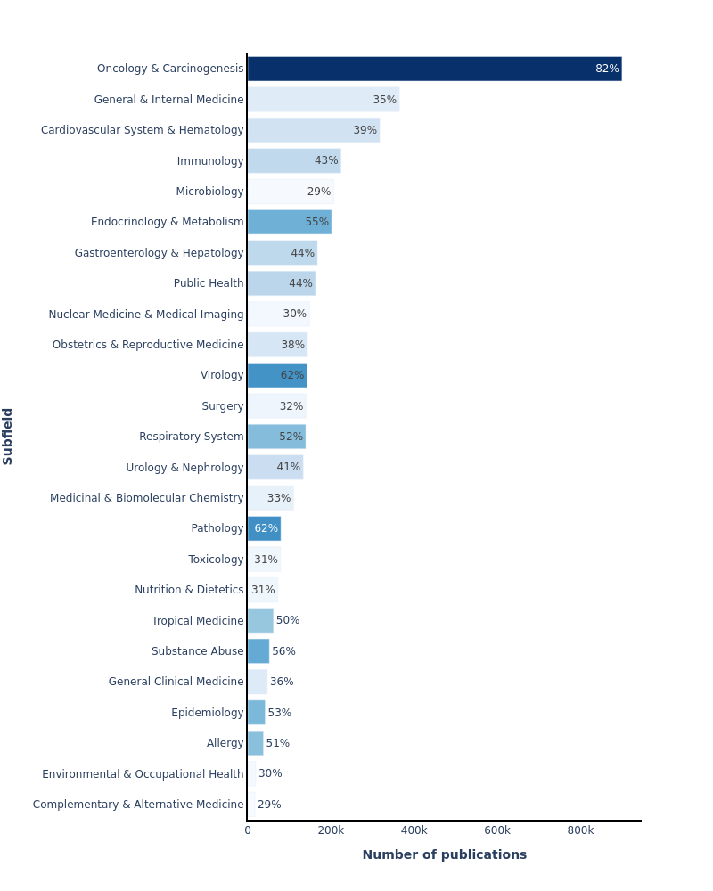

## Journals

In this section, we show how the publication set, captured by the query above, relates to scholarly journals. Journals are sorted in terms of their relevance using term frequency-inverse document frequency (TF-IDF). The horizontal bars are proportional to the number of publications contributed by the journal to the current publication set. The number alongside the horizontal bar is the proportion of the journal contributing to this publication set.

The articles on this topic are published most frequently in the following journals: *PLoS ONE* (79,935 publications), *Scientific Reports* (32,206), and *Cancer Research* (23,491).

Note, larger journals may not appear in the table below, as their SDG contribution may be relatively small compared to the size of the journal.

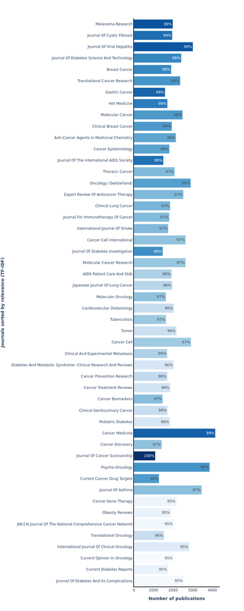

Figure 2. Top 50 journals, in terms of relevance (TF-IDF), for this publication set.

## Keywords

Elsevier’s [Scopus](https://www.scopus.com/search/form.uri?display=basic#basic) database of scientific literature, was used for the table below. The document types included in the data sets are journal articles, reviews, short surveys and conference papers, covering the period 1996–2022. We refer to these documents collectively as “publications” or “papers”.

In order to help better illustrate the content of this set of publications, indicators associated with the keywords most specific to this set (according to a TF-IDF score) are presented below.

|  | Term | # of papers with this term in the publication set | # of papers with this term in all of Scopus | Relevance (TF-IDF) | Percentage of Scopus |
| --- | --- | --- | --- | --- | --- |
| 1 | international association for the study of lung cancer | 2214 | 2271 | 18.8659 | 97 |
| 2 | european prospective investigation into cancer | 1539 | 1572 | 18.8492 | 98 |
| 3 | national institutes of health stroke scale score | 1630 | 1674 | 18.8465 | 97 |
| 4 | sustained virological response (svr) | 2415 | 2501 | 18.8462 | 97 |
| 5 | kaposi's sarcoma-associated herpesvirus | 2065 | 2140 | 18.8459 | 96 |
| 6 | plasma hiv-1 rna | 1413 | 1440 | 18.8402 | 98 |
| 7 | functional assessment of cancer therapy | 2523 | 2621 | 18.8383 | 96 |
| 8 | european prospective investigation into cancer and nutrition | 1371 | 1396 | 18.8365 | 98 |
| 9 | hiv/hcv | 2027 | 2112 | 18.8353 | 96 |
| 10 | breast cancer resistance protein | 2265 | 2363 | 18.8338 | 96 |

[output cut: 990 more lines]